# DTI analysis using stripped files

First, some data cleaning even before we match scans to clinical assessments:

```r
source('~/ncr_notebooks/baseline_prediction/src/aux_functions.R')
tract_data = read.csv('~/data/baseline_prediction/stripped/dti.csv')
# remove data columns from mean_data to avoid duplicates
par(mfrow=c(2, 3))
nbreaks = 40
hist(tract_data$fa_avg, breaks=nbreaks)
hist(tract_data$ad_avg, breaks=nbreaks)
```

```r
hist(tract_data$rd_avg, breaks=nbreaks)
hist(tract_data$norm.trans, breaks=nbreaks)
```

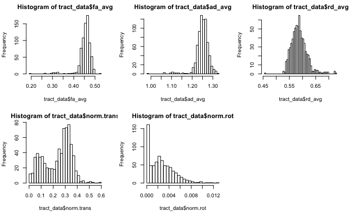

```r
hist(tract_data$norm.rot, breaks=nbreaks)
hist(tract_data$goodSlices, breaks=nbreaks)
```

Cleaning up based on visual cutoffs:

```r
rm_me = (tract_data$fa_avg < .4 | tract_data$ad_avg < 1.18 | tract_data$rd_avg > .65 | tract_data$rd_avg < .5 |
         tract_data$norm.trans > .45 | tract_data$norm.rot > .008 | tract_data$goodSlices < 45 | tract_data$goodSlices > 70)
print(sprintf('Reducing from %d to %d scans', nrow(tract_data), nrow(tract_data)-sum(rm_me)))
```

```
[1] "Reducing from 727 to 656 scans"
```

```r
tract_data = tract_data[!rm_me, ]
```

Now we work under the assumption that all leftover scans are good, so we match them to the baseline clinical of each participant:

```r
gf_fname = '~/data/baseline_prediction/stripped/clinical.csv'
gf = read.csv(gf_fname)
gf = gf[gf$BASELINE=='BASELINE', ]
my_ids = intersect(gf$MRN, tract_data$MRN)
merged = mergeOnClosestDate(gf, tract_data, my_ids)
```

Finally, let’s remove anyone with difference between clinical and scan that’s too big:

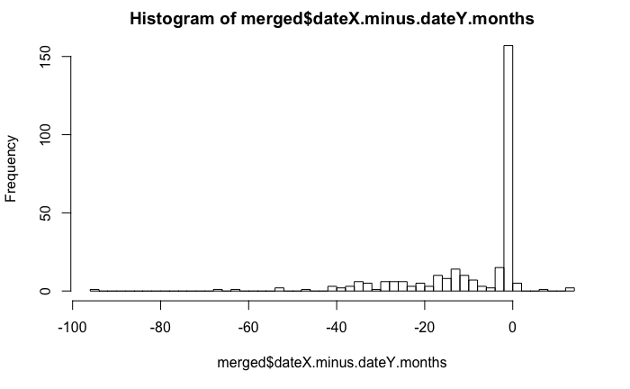

```r
hist(merged$dateX.minus.dateY.months, breaks=nbreaks)
```

There is clearly a big spread. Let’s err in the side of caution and cap it to 1 year before or after:

```r
rm_me = abs(merged$dateX.minus.dateY.months) > 12
print(sprintf('Reducing from %d to %d scans', nrow(merged), nrow(merged)-sum(rm_me)))
```

```
[1] "Reducing from 289 to 200 scans"
```

```r
merged = merged[!rm_me, ]
```

Ready for some ML. Let’s get all features first, and try some NV vs ADHD classification, clumping in the ADHD_NOS folks:

```r
library(caret)
library(randomForest)
seed = 107
phen_vars = c(which(grepl("^FA_", colnames(merged))),
              which(grepl("^AD_", colnames(merged))),
              which(grepl("^RD_", colnames(merged))),
              which(grepl("^MO_", colnames(merged)))
              )
X = merged[, phen_vars]
y = merged$DX_BASELINE
y[y != 'NV'] = 'ADHD'
y = factor(y)
```

By adding MO, we have a few variables that have NAs. We could impute, not use the variables, or remove subjects. All valid approaches, and the imputation could potentially be done in CV. For now, let’s see how many subjects we remove… using colSums and rowSums, only 2 variables, and 2 subjects. Let’s remove subjects for now.

```r
rm_me = rowSums(is.na(X)) > 0
X = X[!rm_me, ]
y = y[!rm_me]
```

```
mtry = 6  OOB error = 42.64%
Searching left ...
mtry = 4    OOB error = 41.12%
0.03571429 1e-05
mtry = 3    OOB error = 40.1%
0.02469136 1e-05
mtry = 2    OOB error = 42.13%
-0.05063291 1e-05
Searching right ...
mtry = 9    OOB error = 40.61%
-0.01265823 1e-05
```

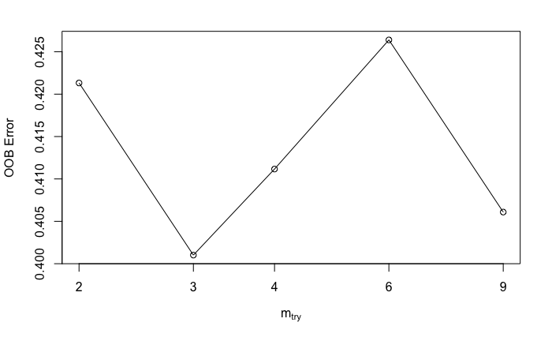

```r
ctrl = trainControl(method="repeatedcv", number=10, repeats=5, selectionFunction = "tolerance")
in_train = createDataPartition(y, p=.8, list=FALSE)
set.seed(seed)
bestmtry <- tuneRF(X, y, stepFactor=1.5, improve=1e-5, ntreeTry=500, subset=in_train)
```

```r
print(bestmtry)
```

```
      mtry  OOBError
2.OOB    2 0.4213198
3.OOB    3 0.4010152
4.OOB    4 0.4111675
6.OOB    6 0.4263959
9.OOB    9 0.4060914
```

Try some RFE:

```r
subsets <- c(1:5, 10, 15, 20, 25)
rfe_ctl <- rfeControl(functions = rfFuncs,
                   method = "repeatedcv",
                   repeats = 5,
                   verbose = FALSE)

rf_RFE <- rfe(X, y, sizes = subsets, rfeControl = rfe_ctl)
print(rf_RFE)
```

[output not shown]

Still nothing to write home about… let’s do our old XGBoost to see if we can get anything else out of it.

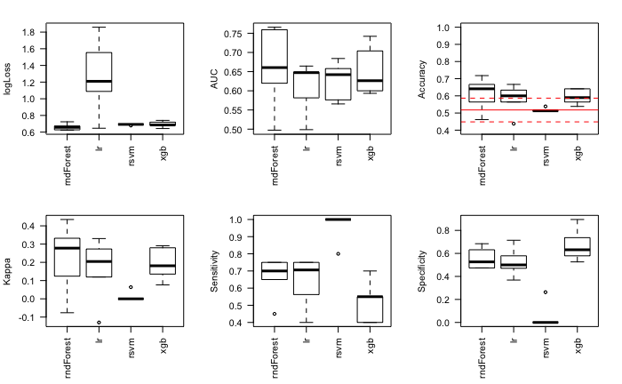

```r
ldata = X
groups = y
root_fname = '~/data/baseline_prediction/results/stripped_allDTI_NVvsADHD'
save(ldata, groups, file=sprintf('%s.RData', root_fname), compress=T)
#runInCluster(root_fname, train_test_ratio=.8, cpuDiff=2, run_models=c('rndForest', 'lr', 'rsvm', 'xgb'))
res = collect_results(root_fname)
mylist = res[[1]]
run_models = res[[2]]
source('~/ncr_notebooks/baseline_prediction/src/do_metrics_plots.R')
```

So, we can better distribution, let’s run it for a few more splits:

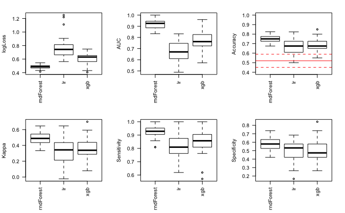

```r
ldata = X
groups = y
root_fname = '~/data/baseline_prediction/results/stripped_allDTI_NVvsADHD_big'
save(ldata, groups, file=sprintf('%s.RData', root_fname), compress=T)
#runInCluster(root_fname, train_test_ratio=.8, cpuDiff=2, nsplits=30, nrepeatcv=5, run_models=c('rndForest', 'lr', 'xgb'))
res = collect_results(root_fname)
mylist = res[[1]]
run_models = res[[2]]
source('~/ncr_notebooks/baseline_prediction/src/do_metrics_plots.R')
```

Now, I did a quick analysis to see how to best split baseline GAS into 2 groups:

```r
myc = kmeans(merged$GAS...GAS, 2)
print(sprintf('Cutoff: %.2f', myc$centers[1] + diff(myc$centers)/2))
```

```
[1] "Cutoff: 77.13"
```

So, would it be easier to classify GAS below or above 77?

```r
yGas = vector(length=length(y))
yGas[merged$GAS...GAS < 77] = 'impaired'
yGas[merged$GAS...GAS >= 77] = 'normal'
yGas = factor(yGas)
```

But we should also make sure we are looking at baseline GAS, by removing anyone who didn’t have the assessment too close:

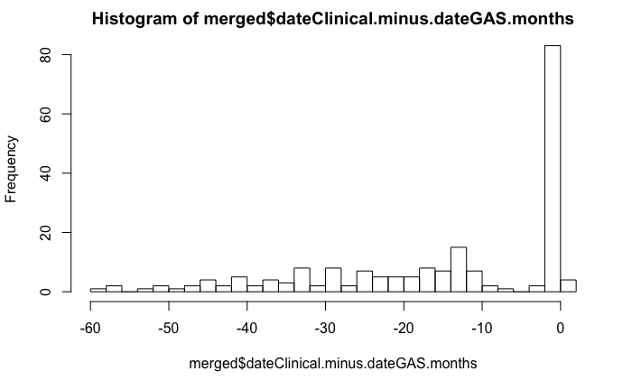

```r
hist(merged$dateClinical.minus.dateGAS.months, breaks=nbreaks)
```

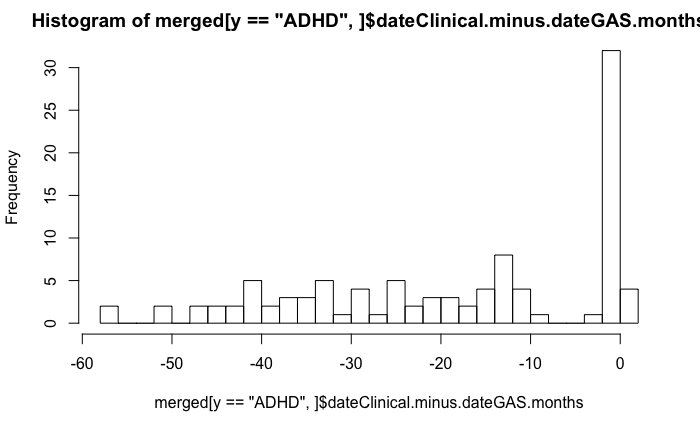

```r
hist(merged[y=='ADHD',]$dateClinical.minus.dateGAS.months, breaks=nbreaks)
```

Still not good. Will get better values from Wendy.